# Poisoning Analysis

**MY WEBSITE**

How did you become **sick** ?

**Summary**  
**I** - Data Introduction  
**A** - First taking of information  
**B** - Data Cleaning  
**II** - Machine Learning Algorithms  
**A** - Random Forest  
**a**. Location & Date  
**b**. Food & Place  
**B** - Decision Tree

**PART I: DATA INTRODUCTION**  
**I. A - First Taking of Information**  
We want to know what are the factors which cause an hospitalization after eating.  
First we load our data and show the original length.  
Then we display the 5 first lines of our dataframe in order to know the content of our base

```python
import pandas as pd
import numpy as np
from os import path

#Create first dataframe from poisoning.csv file
poisoning_df = pd.read_csv("data/poisoning.csv", sep=',')
print("poisoning.csv size :", len(poisoning_df))

poisoning_df.head()
```

```
poisoning.csv size : 19119
```

|  | Year | Month | State | Location | Food | Ingredient | Species | Serotype/Genotype | Status | Illnesses | Hospitalizations | Fatalities |
| --- | --- | --- | --- | --- | --- | --- | --- | --- | --- | --- | --- | --- |
| 0 | 1998 | January | California | Restaurant | NaN | NaN | NaN | NaN | NaN | 20 | 0.0 | 0.0 |
| 1 | 1998 | January | California | NaN | Custard | NaN | NaN | NaN | NaN | 112 | 0.0 | 0.0 |
| 2 | 1998 | January | California | Restaurant | NaN | NaN | NaN | NaN | NaN | 35 | 0.0 | 0.0 |
| 3 | 1998 | January | California | Restaurant | Fish, Ahi | NaN | Scombroid toxin | NaN | Confirmed | 4 | 0.0 | 0.0 |
| 4 | 1998 | January | California | Private Home/Residence | Lasagna, Unspecified; Eggs, Other | NaN | Salmonella enterica | Enteritidis | Confirmed | 26 | 3.0 | 0.0 |

**I. B - Data Cleaning**

```python
del poisoning_df["Fatalities"]
del poisoning_df["Illnesses"]
```

Now we deleted unused columns, we can take a look at our target column which is naturally "Hospitalization".  
We will first check if our column contains NaN value.

```python
print("Hospitalizations NA:", pd.isnull(poisoning_df.Hospitalizations).values.any())
```

```
Hospitalizations NA: True
```

As target value cannot be NaN and as we can't replace NaN by mean or something else we will delete every Hospitalization lines containing NaN.  
We don't do dropna because we want to keep some information in other lines.  
Then we will globalize our target in two value, either their is Hospitalization: 1 or not: 0.  
We will display the new length of our dataframe.

```python
poisoning_df = poisoning_df[np.isfinite(poisoning_df['Hospitalizations'])]
poisoning_df['Hospitalizations_Global'] = np.where(poisoning_df.Hospitalizations > 0, 1, 0)
print("Hospitalization value count:")
print(poisoning_df.Hospitalizations_Global.value_counts())
print("\nNew size poisoning_df:", len(poisoning_df))
```

```
Hospitalization value count:
0    11439
1     4055
Name: Hospitalizations_Global, dtype: int64

New size poisoning_df: 15494
```

We will begin by work on columns which are easily workable.  
So we will create a 'Season' column according to the months in order to have less group for our Random Forest and knowing that in term of bacteria and virus, January and February are close.  
We don't forget to create a column encoded that we will use after for our Random Forest.

```python
def detect_season(df):
  season = df.Month
  if (season == "January") | (season == "February") | (season == "March"):
    return 0
  if (season == "April") | (season == "May") | (season == "June"):
    return 1
  if (season == "July") | (season == "August") | (season == "September"):
    return 2
  else:
    return 3

poisoning_df["Season"] = poisoning_df.apply(detect_season, axis=1)
```

Having do that we will do almost the same with States.  
The idea is to search on internet which are the states producing the most food, supposing that it import less and keep a good food quality.  
We will do exactly the same with fishing, repertoring states bordering the sea.

```python
def detect_producer(df):
  state = df.State
  #results found on http://beef2live.com/story-states-produce-food-value-0-107252
  if ((state == "California") | (state == "Iwoa") | (state == "Nebraska")
      | (state == "Texas") | (state == "Minnesota")):
    return 1
  else:
    return 0

def detect_fishing(df):
  state = df.State
  #results found on https://en.wikipedia.org/wiki/Fishing_industry_in_the_United_States
  if ((state == "California") | (state == "Oregon") | (state == "Washington")
      | (state == "Texas") | (state == "Louisiana") | (state == "Mississippi")|
      (state == "North Carolina") | (state == "South Carolina") |
      (state == "Georgia")| (state == "Virgina") | (state == "Maine") |
      (state == "Maryland") | (state == "Michigan")| (state == "Wisconsin") |
      (state == "Alaska")):
    return 1
  else:
    return 0

poisoning_df["ProducerState"] = poisoning_df.apply(detect_producer, axis=1)
poisoning_df["FishingState"] = poisoning_df.apply(detect_fishing, axis=1)

#Encode the state.
from sklearn import preprocessing
label_encoder = preprocessing.LabelEncoder()
poisoning_df["StateEncoder"] = label_encoder.fit_transform(poisoning_df["State"])
```

Earlier we have seen that the "Location" column contains a lot of different values.  
The first thing we will do is to display the 50 most used values in this columns.

```python
LocValue = poisoning_df.Location.value_counts()
n = range(50)

for i in n: #Display 50 most used values in Location
  print(LocValue[[i]], "\n")
```

```
Restaurant    8291
Name: Location, dtype: int64

Private Home/Residence    1457
Name: Location, dtype: int64

Catering Service    897
Name: Location, dtype: int64

Fast Food Restaurant    361
Name: Location, dtype: int64

Banquet Facility    345
Name: Location, dtype: int64

School/College/University    272
Name: Location, dtype: int64

Unknown    266
Name: Location, dtype: int64

Grocery Store    237
Name: Location, dtype: int64

Restaurant; Private Home/Residence    180
Name: Location, dtype: int64

Prison/Jail    164
Name: Location, dtype: int64

Nursing Home/Assisted Living Facility    151
Name: Location, dtype: int64

Restaurant; Catering Service    131
Name: Location, dtype: int64

Camp    100
Name: Location, dtype: int64

Religious Facility    100
```

[output cut: 94 more lines]

```

Restaurant; Religious Facility    4
Name: Location, dtype: int64

Office/Indoor Workplace; Hospital    4
Name: Location, dtype: int64

Restaurant; Catering Service; Grocery Store    4
Name: Location, dtype: int64

Restaurant; Private Home/Residence; Fair/Festival    4
Name: Location, dtype: int64

Restaurant; Camp    4
Name: Location, dtype: int64
```

As we can see, there is a lot of different values in this column.  
For example, we can see that the most used location is "Restaurant" and we can see that this word is present in many other raws like "Fast Food Restaurant" or "Restaurant; Private Home/Residence".  
Our work will be to create a column "Restaurant" indicating if the restaurant word is present or not in the raw.

First we will put every words in lower letters in order to avoid the casse.  
Secondly we will extract all 'restaurant' words in the 'Location' column. The "isRestaurant" column will have either NaN value or "restaurant" if Location contains 'restaurant'.  
Thirdly we just remplace NaN values by 'NO' in uppercase in order to have the same encoding for every columns.

```python
poisoning_df.Location = poisoning_df.Location.str.lower()
poisoning_df["isRestaurant"] = poisoning_df.Location.str.extract('.*(restaurant).*', expand=False).str.strip()
poisoning_df["isRestaurant"] = poisoning_df["isRestaurant"].fillna("NO")
```

Fourth we will encode our value 1 if it is a restaurant, otherwise (NO) 0.

```python
poisoning_df["isRestaurant"] = label_encoder.fit_transform(poisoning_df["isRestaurant"])
poisoning_df.head()
```

|  | Year | Month | State | Location | Food | Ingredient | Species | Serotype/Genotype | Status | Hospitalizations | Hospitalizations_Global | Season | ProducerState | FishingState | StateEncoder | isRestaurant |
| --- | --- | --- | --- | --- | --- | --- | --- | --- | --- | --- | --- | --- | --- | --- | --- | --- |
| 0 | 1998 | January | California | restaurant | NaN | NaN | NaN | NaN | NaN | 0.0 | 0 | 0 | 1 | 1 | 4 | 1 |
| 1 | 1998 | January | California | NaN | Custard | NaN | NaN | NaN | NaN | 0.0 | 0 | 0 | 1 | 1 | 4 | 0 |
| 2 | 1998 | January | California | restaurant | NaN | NaN | NaN | NaN | NaN | 0.0 | 0 | 0 | 1 | 1 | 4 | 1 |
| 3 | 1998 | January | California | restaurant | Fish, Ahi | NaN | Scombroid toxin | NaN | Confirmed | 0.0 | 0 | 0 | 1 | 1 | 4 | 1 |
| 4 | 1998 | January | California | private home/residence | Lasagna, Unspecified; Eggs, Other | NaN | Salmonella enterica | Enteritidis | Confirmed | 3.0 | 1 | 0 | 1 | 1 | 4 | 0 |

We created a magic function efficient for each column we will choose and for each word we will want.  
Having the column name "isXx" for the word "xx"  
We just have to create a list of columns containing the "isWord" we want to find.

```python
def create_columns(grepColumn, newColumns):
  grepWords = []
  for n in newColumns:
    n = n.lower()
    n = n[2:]
    grepWords.append(n)

  for n, t in zip(newColumns, grepWords):
    poisoning_df[n] = grepColumn.str.extract('.*(' + t +').*', expand=False).str.strip()

  for n in newColumns:
    poisoning_df[n] = poisoning_df[n].fillna("NON")

  for n in newColumns:
    poisoning_df[n] = label_encoder.fit_transform(poisoning_df[n])
#########END FUNCTION#########

newLocationColumn = ["isRestaurant","isResidence","isHome","isCatering","isFastFood","isBanquet",
                    "isSchool","isStore","isPrison","isNurse","isCamp","isReligious","isOffice",
                    "isFestival","isHospital", "isFarm"]

poisoning_df.Location = poisoning_df.Location.str.lower()
create_columns(poisoning_df.Location, newLocationColumn)
```

Now we can do exactly the same work with Food column.

```python
FoodValue = poisoning_df.Food.value_counts()
n = range(100)

for i in n: #Display 50 most used values in Food
  print(FoodValue[[i]], "\n")
```

```
Oysters, Raw    132
Name: Food, dtype: int64

Multiple Foods    129
Name: Food, dtype: int64

Salad, Unspecified    92
Name: Food, dtype: int64

Ground Beef, Hamburger    75
Name: Food, dtype: int64

Chicken, Unspecified    69
Name: Food, dtype: int64

Fish, Mahi Mahi    68
Name: Food, dtype: int64

Sandwich, Submarine    68
Name: Food, dtype: int64

Pork, Bbq    63
Name: Food, dtype: int64

Lettuce-Based Salads Unspecified    61
Name: Food, dtype: int64

Chicken, Other    60
Name: Food, dtype: int64

Chicken Salad    55
Name: Food, dtype: int64

Potato Salad    53
Name: Food, dtype: int64

Ice    50
Name: Food, dtype: int64

Tuna, Unspecified    50
```

[output cut: 244 more lines]

```

Queso Fresco, Unpasteurized    15
Name: Food, dtype: int64

Other Milk, Unpasteurized    15
Name: Food, dtype: int64

Mushrooms    15
Name: Food, dtype: int64

Salmon, Unspecified    15
Name: Food, dtype: int64

Sandwich, Ham    15
Name: Food, dtype: int64
```

We will create our column according to the most used values in food.  
And we can have an idea of what we did by displaying the 5 first rows of our dataframe.

```python
newFoodColumn = ["isOysters", "isSalad", "isMultiple", "isUnspecified", "isSandwich", "isFish",
                 "isPork", "isChicken", "isBbq", "isPotato", "isTuna", "isIce", "isDeli",
                "isPizza", "isMeat", "isMilk", "isCake", "isBeef", "isRice", "isEthnic",
                 "isColeslaw", "isBeans", "isFruit", "isSushi", "isCheeseburger", "isEggs",
                "isSteak", "isCantaloupe", "isGuacamole", "isHam", "isTomato", "isLettuce",
                 "isMushrooms"]

poisoning_df.Food = poisoning_df.Food.str.lower()
create_columns(poisoning_df.Food, newFoodColumn)

poisoning_df.head()
```

|  | Year | Month | State | Location | Food | Ingredient | Species | Serotype/Genotype | Status | Hospitalizations | ... | isSushi | isCheeseburger | isEggs | isSteak | isCantaloupe | isGuacamole | isHam | isTomato | isLettuce | isMushrooms |
| --- | --- | --- | --- | --- | --- | --- | --- | --- | --- | --- | --- | --- | --- | --- | --- | --- | --- | --- | --- | --- | --- |
| 0 | 1998 | January | California | restaurant | NaN | NaN | NaN | NaN | NaN | 0.0 | ... | 0 | 0 | 0 | 0 | 0 | 0 | 0 | 0 | 0 | 0 |
| 1 | 1998 | January | California | NaN | custard | NaN | NaN | NaN | NaN | 0.0 | ... | 0 | 0 | 0 | 0 | 0 | 0 | 0 | 0 | 0 | 0 |
| 2 | 1998 | January | California | restaurant | NaN | NaN | NaN | NaN | NaN | 0.0 | ... | 0 | 0 | 0 | 0 | 0 | 0 | 0 | 0 | 0 | 0 |
| 3 | 1998 | January | California | restaurant | fish, ahi | NaN | Scombroid toxin | NaN | Confirmed | 0.0 | ... | 0 | 0 | 0 | 0 | 0 | 0 | 0 | 0 | 0 | 0 |
| 4 | 1998 | January | California | private home/residence | lasagna, unspecified; eggs, other | NaN | Salmonella enterica | Enteritidis | Confirmed | 3.0 | ... | 0 | 0 | 1 | 0 | 0 | 0 | 0 | 0 | 0 | 0 |

5 rows × 64 columns

Now, we have all the columns we need to begin our prediction.

**PART II: MACHINE LEARNING**  
**II. A. a - Random Forest:** *Location & Date*  
First, we will make a prediction using Random Forest algorithm on our main initial columns corresponding to location and date.  
And directly show the result voluntarily. In the next part our approach will be detailed.

```python
import numpy as np
import matplotlib.pyplot as plt
from sklearn.ensemble import RandomForestClassifier as RandomForest
from pandas import DataFrame
from sklearn.cross_validation import train_test_split

target = poisoning_df.Hospitalizations_Global

features_without_datacleaning = ["StateEncoder", "Season", "Year"]
predictors = poisoning_df[features_without_datacleaning]

split = train_test_split(poisoning_df, target, test_size=0.4, random_state=42)
data_train, data_test, target_train, target_test = split

model = RandomForest(n_estimators=10)
model.fit(data_train[features_without_datacleaning], target_train)

print(model.score(data_test[features_without_datacleaning], target_test))
```

```
0.72136172959
```

**II. A. b - Random Forest:** *Food & Place*  
Now that we have done our prediction over initial data we will do the same with the columns we created for food and place. The idea is to make a prediction more complex over things a person can manage like the food he'll eat and the place he'll go.  
To do that we recovered in a same list both of location and food columns we created before, as feature.  
Using the same target we performed a bootstrap (recover 40% 15494->40%->6198 random data of poisoning_df data set)

```python
features = []
for c, l in zip(newLocationColumn, newFoodColumn):
    features.append(c)
    features.append(l)

predictors = poisoning_df[features]

split = train_test_split(poisoning_df, target, test_size=0.4, random_state=42)
data_train, data_test, target_train, target_test = split
print('full shape:', poisoning_df.shape, '\ntest shape:', data_test.shape, '\ntrain shape:', data_train.shape)
```

```
full shape: (15494, 64)
test shape: (6198, 64)
train shape: (9296, 64)
```

Once our RandomForest will be performed, we will display the importance of each column.

```python
model = RandomForest(n_estimators=10)
model.fit(data_train[features], target_train)
importances = model.feature_importances_
std = np.std([tree.feature_importances_ for tree in model.estimators_], axis=0)

for feature, imp, i in zip(features, importances, range(len(features))):
    print("  %d. %s -> %f" % (i+1, feature, imp))
```

```
  1. isRestaurant -> 0.130543
  2. isOysters -> 0.014663
  3. isResidence -> 0.075548
  4. isSalad -> 0.037994
  5. isHome -> 0.056018
  6. isMultiple -> 0.019562
  7. isCatering -> 0.061179
  8. isUnspecified -> 0.066417
  9. isFastFood -> 0.000000
  10. isSandwich -> 0.036128
  11. isBanquet -> 0.039015
  12. isFish -> 0.022901
  13. isSchool -> 0.035728
  14. isPork -> 0.028617
  15. isStore -> 0.041927
  16. isChicken -> 0.046343
  17. isPrison -> 0.010959
  18. isBbq -> 0.019341
  19. isNurse -> 0.000000
  20. isPotato -> 0.027486
  21. isCamp -> 0.019621
  22. isTuna -> 0.030448
  23. isReligious -> 0.020148
  24. isIce -> 0.038491
  25. isOffice -> 0.016197
  26. isDeli -> 0.011305
  27. isFestival -> 0.019811
  28. isPizza -> 0.012945
  29. isHospital -> 0.010071
  30. isMeat -> 0.023511
  31. isFarm -> 0.000523
  32. isMilk -> 0.026559
```

We create now a dataframe in order to sort the most important feature by score, taking care to keep the error estimation for the plot you will see below.  
Then from this dataframe, we create another one keeping the 10 most important features.

```python
variable_name = []
variable_score = []
variable_std = []
for f, imp, mystd in zip(features, model.feature_importances_, std):
    variable_name.append(f)
    variable_score.append(imp)
    variable_std.append(mystd)

index = range(len(variable_name))
d = {
    'Variable_Name': variable_name,
    'Variable_Score': variable_score,
    'Variable_Std': variable_std
    }
variable_importance_df = DataFrame(data=d, index=index)
variable_importance_df = variable_importance_df.sort_values(by = 'Variable_Score', ascending=False)
variable_importance_TOP10_df = variable_importance_df.head(10)
variable_importance_TOP10_df
```

|  | Variable_Name | Variable_Score | Variable_Std |
| --- | --- | --- | --- |
| 0 | isRestaurant | 0.130543 | 0.044245 |
| 2 | isResidence | 0.075548 | 0.041276 |
| 7 | isUnspecified | 0.066417 | 0.025320 |
| 6 | isCatering | 0.061179 | 0.021695 |
| 4 | isHome | 0.056018 | 0.031893 |
| 15 | isChicken | 0.046343 | 0.020102 |
| 14 | isStore | 0.041927 | 0.012893 |
| 10 | isBanquet | 0.039015 | 0.019954 |
| 23 | isIce | 0.038491 | 0.008395 |
| 3 | isSalad | 0.037994 | 0.020556 |

From this 10 dataframe lines we create a plot showing well the importance of each variable one against the other.

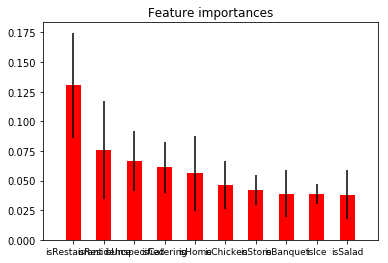

```python
# Plot the feature importances of the RF
plt.figure()
plt.title("Feature importances")
plt.bar(
        range(len(variable_importance_TOP10_df)),
        np.array(variable_importance_TOP10_df['Variable_Score']),
        color="r",
        yerr=np.array(variable_importance_TOP10_df['Variable_Std']),
        align="center",
        width=0.5
       )
plt.xticks(
            range(len(variable_importance_TOP10_df)),
            np.array(variable_importance_TOP10_df['Variable_Name']),
            fontsize=9
          )
plt.xlim([-1, len(variable_importance_TOP10_df)])
plt.show()
```

```python
import sklearn

features_TOP10 = np.array(variable_importance_TOP10_df['Variable_Name'])
predictors = poisoning_df[features_TOP10]
split = train_test_split(poisoning_df, target, test_size=0.4, random_state=42)
data_train, data_test, target_train, target_test = split

model = RandomForest(n_estimators=10)
model.fit(data_train[features_TOP10], target_train)
prediction = model.predict(data_test[features_TOP10])

print("Confusion matrix:\n", sklearn.metrics.confusion_matrix(target_test, prediction))
print("\nThe score:\n", model.score(data_test[features_TOP10], target_test))
```

```
Confusion matrix:
 [[4496   86]
 [1540   76]]

The score:
 0.737657308809
```

From now our work will be to improve this pretty good score.  
We will use get_features_importance function created in student notebook doing almost what we have done above and improve it returning an array composed of a dataframe and a score.

```python
def get_features_importance(arg_dataframe, arg_columntarget, arg_features, arg_topNumber):

  predictors = arg_dataframe[arg_features]#student_df[arg_features]
  target = arg_columntarget#student_df.Global_Marks

  split = train_test_split(arg_dataframe, target, test_size=0.4, random_state=42)
  data_train, data_test, target_train, target_test = split

  model = RandomForest(n_estimators=10)
  model.fit(data_train[arg_features], target_train)
  importances = model.feature_importances_
  std = np.std([tree.feature_importances_ for tree in model.estimators_], axis=0)

  variable_name = []
  variable_score = []
  variable_std = []
  for f, imp, mystd in zip(arg_features, model.feature_importances_, std):
    variable_name.append(f)
    variable_score.append(imp)
    variable_std.append(mystd)

  index = range(len(variable_name))
  d = {
    'Variable_Name': variable_name,
    'Variable_Score': variable_score,
    'Variable_Std': variable_std
  }
  variable_importance_df = DataFrame(data=d, index=index)
  variable_importance_df = variable_importance_df.sort_values(by = 'Variable_Score', ascending=False)
  variable_importance_TOP_df = variable_importance_df.head(arg_topNumber)

  features_TOP = np.array(variable_importance_TOP_df['Variable_Name'])
  predictors = arg_dataframe[features_TOP]

  model = RandomForest(n_estimators=10)
  model.fit(data_train[features_TOP], target_train)
  prediction = model.predict(data_test[features_TOP])

  TOP_score = model.score(data_test[features_TOP], target_test)

  resultArray = [variable_importance_TOP_df, TOP_score]

  return(resultArray)
###END FUNCTION###
```

An idea I had in order to improve my score was to create 3 new columns.  
"Sea" composed of fish, oysters etc.  
A second "Vegetable" column and another one named "Meat".

```python
def sea_food(df):
  oysters = df.isOysters
  fish = df.isFish
  tuna = df.isTuna
  sushi = df.isSushi
  if (oysters == 1) | (fish == 1) | (tuna == 1) | (sushi == 1):
    return 1
  else:
    return 0

poisoning_df["Sea"] = poisoning_df.apply(sea_food, axis=1)
```

```python
def vegetable_food(df):
  salad = df.isSalad
  potato = df.isPotato
  beans = df.isBeans
  coleslaw = df.isColeslaw
  cantaloupe = df.isCantaloupe
  guacamole = df.isGuacamole
  tomato = df.isTomato
  lettuce = df.isLettuce
  mushrooms = df.isMushrooms
  if ((salad == 1) | (potato == 1) | (beans == 1) | (coleslaw == 1)
      | (cantaloupe == 1) | (guacamole == 1) | (tomato == 1) |
      (lettuce == 1)| (mushrooms == 1)):
    return 1
  else:
    return 0

poisoning_df["Vegetable"] = poisoning_df.apply(vegetable_food, axis=1)
```

```python
def meat_food(df):
  pork = df.isPork
  chicken = df.isChicken
  bbq = df.isBbq
  deli = df.isDeli
  meat = df.isMeat
  beef = df.isBeef
  cheeseburger = df.isCheeseburger
  ham = df.isHam
  if ((pork == 1) | (chicken == 1) | (bbq == 1) | (deli == 1)
      | (meat == 1) | (beef == 1) | (cheeseburger == 1) | (ham == 1)):
    return 1
  else:
    return 0

poisoning_df["Meat"] = poisoning_df.apply(meat_food, axis=1)
```

Now we can add those 3 columns to our features.

```python
#Be careful to not run this cell two times.
newfeatures1 = []
newfeatures1 = features
newfeatures1.append("Sea")
newfeatures1.append("Vegetable")
newfeatures1.append("Meat")
```

And use our magic function taking new features as argument.

```python
RF_result = get_features_importance(poisoning_df, poisoning_df.Hospitalizations_Global, newfeatures1, 10)
print("Global score:", RF_result[1])
RF_result[0]
```

```
Global score: 0.741368183285
```

|  | Variable_Name | Variable_Score | Variable_Std |
| --- | --- | --- | --- |
| 0 | isRestaurant | 0.128406 | 0.025255 |
| 6 | isCatering | 0.081548 | 0.019472 |
| 7 | isUnspecified | 0.075104 | 0.018650 |
| 4 | isHome | 0.056567 | 0.046574 |
| 2 | isResidence | 0.049556 | 0.036091 |
| 3 | isSalad | 0.043010 | 0.012122 |
| 33 | Vegetable | 0.041891 | 0.011550 |
| 34 | Meat | 0.038903 | 0.016405 |
| 23 | isIce | 0.037126 | 0.004717 |
| 10 | isBanquet | 0.034410 | 0.013830 |

Another idea I had was to create a column highlighting the person who have eaten fish in a state which don't border the sea meaning that the fish was imported.

```python
def imported_fish(df):
  fish = df.isFish
  fishingstate = df.FishingState
  if (fish == 1) & (fishingstate == 0):
    return 1
  else:
    return 0

poisoning_df["Eat_Imported_Fish"] = poisoning_df.apply(imported_fish, axis=1)
```

```python
#Be careful to not run this cell two times.
newfeatures2 = []
newfeatures2 = newfeatures1
newfeatures2.append("Eat_Imported_Fish")
```

```python
RF_result = get_features_importance(poisoning_df, poisoning_df.Hospitalizations_Global, newfeatures2, 10)
print("Global score:", RF_result[1])
RF_result[0]
```

```
Global score: 0.739109390126
```

|  | Variable_Name | Variable_Score | Variable_Std |
| --- | --- | --- | --- |
| 0 | isRestaurant | 0.137780 | 0.030224 |
| 7 | isUnspecified | 0.076597 | 0.017017 |
| 6 | isCatering | 0.068966 | 0.011415 |
| 4 | isHome | 0.055431 | 0.042569 |
| 2 | isResidence | 0.047767 | 0.035482 |
| 33 | Vegetable | 0.044168 | 0.018252 |
| 14 | isStore | 0.043765 | 0.012090 |
| 34 | Meat | 0.038658 | 0.012773 |
| 23 | isIce | 0.036774 | 0.008871 |
| 9 | isSandwich | 0.032576 | 0.013933 |

Unfortunately, this time my idea was not as good as I hoped because the new feature is not in the top 10.  
Nevertheless, the score is pretty good for data which was unworkable some cells ago.  
So with random forest we have succeeded a prediction improvement which finally reach a score of almost 75%, only using pandas skills and from only two "dirty" columns.

**II. B - Decision Tree**  
There is a legend saying that it is very dangerous to eat oysters in a restaurant.  
So I decided to create a decision tree taking into acount those two features.

```
Features: ['isRestaurant', 'isOysters']
Features: ['X[0]', 'X[1]']
```

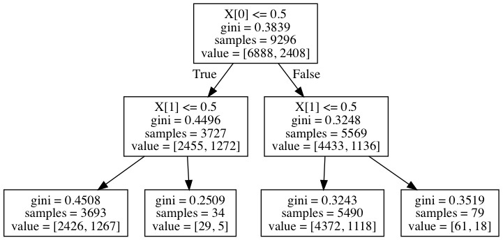

```python
# Need 'brew install graphviz' on terminal for MacOSX
# Or ‘sudo apt-get install graphviz’ for Linux
from sklearn.tree import DecisionTreeClassifier
from sklearn import tree
from io import StringIO
from IPython.display import Image
import pydotplus

#make classifier with our main feature
main_feature = ["isRestaurant", "isOysters"]
features = main_feature
predictors = poisoning_df[features]
pred_train, pred_test, tar_train, tar_test = train_test_split(predictors, target, test_size=.4)
classifier = DecisionTreeClassifier(min_samples_split=20, random_state=10)
classifier = classifier.fit(pred_train, tar_train)

#Draw
print("Features:", main_feature)
print("Features: ['X[0]', 'X[1]']")
out = StringIO()
tree.export_graphviz(classifier, out_file=out)
graph=pydotplus.graph_from_dot_data(out.getvalue())
Image(graph.create_png())
```